# Lyft - Baywheels Data Exploration

### Data from January 2019 to June 2019

## by Gautam Gadiyar

## Introduction

> The Lyft - Baywheels is a Bike sharing company that rents out bikes to customers who may hire a bike from any nearest point. It was a partnership program with Metropolitan Transportation Commission in order to motiate people to use envireonnment friendly means of transport. Beginning operation in August 2013 as Bay Area Bike Share, the Bay Wheels system currently has over 2,600 bicycles in 262 stations across San Francisco, East Bay and San Jose. On June 28, 2017, the system was re-launched as Ford GoBike in a partnership with Ford Motor Company.  
> After Motivate's acquisition by Lyft, the system was subsequently renamed to Bay Wheels in June 2019.The system provides bikes 24/7 to customers at nominal costs. The customers have access to all the bikes once they are a member or have a pass for themselves.

## Preliminary Wrangling

Firstly, the data that has been obtained from the Lyft site has to be checked for any anomalies. The data has to be cleaned and then we can start with the visualizations.

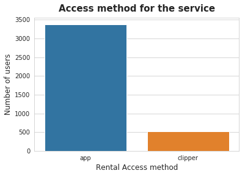

```python
sb.set_style('whitegrid')
sb.barplot(rental_access.index, rental_access);
plt.title('Access method for the service', fontsize=15, fontweight='bold', y=1.02)
plt.ylabel('Number of users', fontsize=12)
plt.xlabel("Rental Access method",fontsize=12)
```

Of the **3893 records** that we have for rental_access_method, it seems most of the bookings came via the app. But since the number is less compared to the total records that we have, it might not be the right result.

## Data Cleaning

There seems to be a few quality issues with the data. The following are a few:

1. The start/end time should be in timestamp datatype. Birth year should be in integer
2. Bike_id, station_id need to be in string format.
3. Birth years might be wrong, since some users are more than 100 years of age.
4. The latitudes and longitudes are not readable by users. Need to calculate the distance travelled.
5. Delete the rental access method

```python
# making a copy for cleaning

master_cleaned = master_df.copy()
```

```python
# changing datatype to datetime
master_cleaned.start_time = pd.to_datetime(master_cleaned.start_time)
master_cleaned.end_time = pd.to_datetime(master_cleaned.end_time)
```

```python
# changing to string
master_cleaned.start_station_id = master_cleaned.start_station_id.astype(str)
master_cleaned.end_station_id = master_cleaned.end_station_id.astype(str)
```

```python
#calculate the age from the year of borth
master_cleaned['member_age'] = datetime.datetime.now().year - master_cleaned.member_birth_year
```

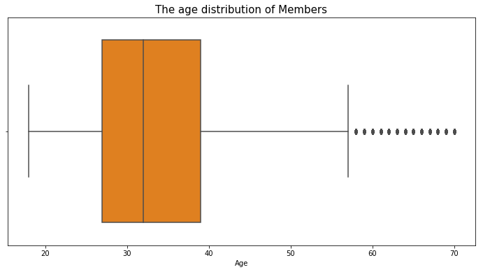

```python
# plot corrected distribution

plt.figure(figsize=(12,6))
sb.boxplot(x='member_age', data=master_cleaned, palette='autumn', orient='h')
plt.title("The age distribution of Members", fontsize=15)
plt.xlabel("Age")
```

**Calculating speed of the rides**

```python
# speed = distance/time formulae
master_cleaned['speed'] = master_cleaned.distance_travelled / (master_cleaned.duration_sec/3600)
master_cleaned.describe().speed
```

```
count    1.241118e+06
mean     1.132278e+01
std      3.785368e+02
min      0.000000e+00
25%      8.137931e+00
50%      1.044000e+01
75%      1.271553e+01
max      2.632576e+05
Name: speed, dtype: float64
```

### What is the structure of your dataset?

The dataset is a collection user rides data that provided the distance, time, station data with most of the data being clean. There are 191772 records dated for June 2019. This gives a very clear insight to the trends. Most values are numeric in the dataset.

The following are the features present:

1. Duration in seconds
2. Start time
3. End_time
4. Start_station_id
5. Start_station_name
6. Start_station_latitude
7. Start_station_longitude
8. End_station_id
9. End_station_name
10. End_station_latitude
11. End_station_longitude
12. Bike_id
13. User_type
14. Member_birth_year
15. Member_gender
16. Bike_share_for_all_trip
17. Member_age
18. Distance_travelled

### What is/are the main feature(s) of interest in your dataset?

Some of the interesting features to look out for are:

1. What age group is most prevalent in using the service.
2. What is the most popular station and the popular destination.
3. Does the distance travelled increase/decrease with age?
4. Is the Bike share for all program taking off well?
5. Is it the members or the casual customers that are using the service more

### What features in the dataset do you think will help support your investigation into your feature(s) of interest?

Any data that is part of the distance, station, user related fields and time will help in getting the insights. We need to check where the footfall is more so that the company can be prepared for better services at those stations. We need to check if any age group need more motivation to use the services. We speed, unique bike is will help in determining the speeds which users take a ride at.

## Univariate Exploration

**Let's see if Baywheels Bike for all is a success**

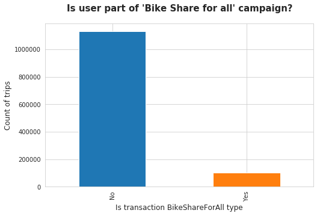

```python
# Count of Yes/No for the campaign
program_count = master_cleaned.bike_share_for_all_trip.value_counts()

#set whitegrid for seaborn plots
sb.set_style('whitegrid')
# set figure size
plt.figure(figsize=(8,5))
# plot a bar chart
program_count.plot(kind='bar')
# set title
plt.title("Is user part of 'Bike Share for all' campaign?",fontsize=15,y=1.05, fontweight='bold');
#set the label on x axis
plt.xlabel("Is transaction BikeShareForAll type",fontsize=12)
#set the label on y axis
plt.ylabel("Count of trips",fontsize=12);
```

**How long do Bike trips generally last?**

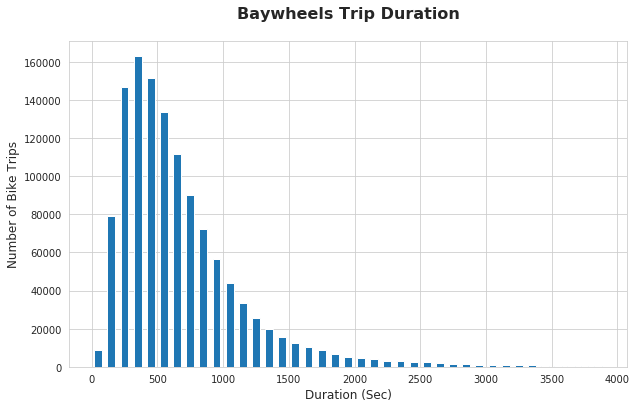

```python
# Duration of the bike rides -in seconds
plt.figure(figsize=(10,6))

# create bins upto 4000 seconds, with 100 sec interval
bin_edges = np.arange(0, 4000, 100)
#plot a histogram
plt.hist(data = master_cleaned, x = 'duration_sec', bins = bin_edges, rwidth = 0.6);

#naming of plots
plt.title("Baywheels Trip Duration", y=1.05, fontsize=16, fontweight='bold')
plt.xlabel('Duration (Sec)',fontsize=12)
plt.ylabel('Number of Bike Trips',fontsize=12);
```

```python
# replace M,F,O
master_cleaned.loc[master_cleaned.member_gender == 'M','member_gender'] = 'Male'
master_cleaned.loc[master_cleaned.member_gender == 'F','member_gender'] = 'Female'
master_cleaned.loc[master_cleaned.member_gender == 'O','member_gender'] = 'Other'

#remove Null valued records of value counts
master_cleaned = master_cleaned[master_cleaned.member_gender.isin(['Male','Female','Other'])]
```

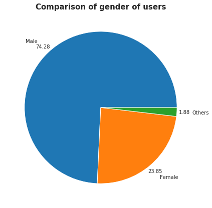

```python
plt.figure(figsize=(7,7))
plt.pie(gender_count, labels = ['Male','Female','Others'], autopct = '%0.2f',labeldistance=1.2, pctdistance=1.1,);
plt.title("Comparison of gender of users", fontsize=15, fontweight='bold');
```

The users are dominated by Males with a whopping 74% users being male and female being 23.85%. This shows that there are a less number of females interested in the service or maybe females do not roam around a lot!

**Distribution of rides by age groups**

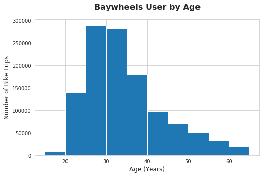

```python
# Age group data
bin_edges = np.arange(15, 70, 5)
plt.figure(figsize=(8,5))
plt.hist(data = master_cleaned, x = 'member_age', bins = bin_edges);

plt.title("Baywheels User by Age", y=1.05, fontsize=16, fontweight='bold')
plt.xlabel('Age (Years)',fontsize=12)
plt.ylabel('Number of Bike Trips',fontsize=12);
```

**The people in the age group of 25 to 40 use the service a lot. This would mostly attribute the working professionals and student who might be staying nearby and use the ride sharing system for travel.**  
There are close to 550K rides taken by users in the age group 25 to 35 that are using the service.

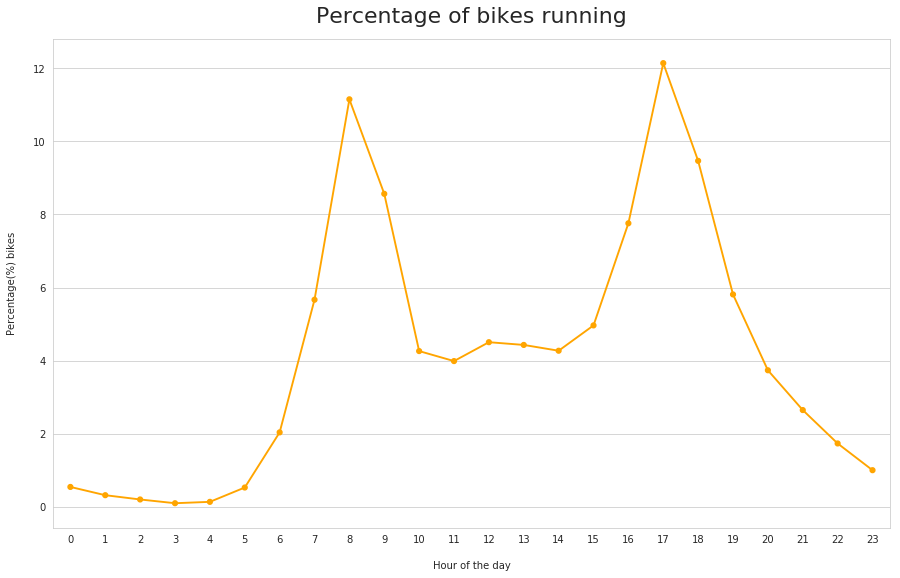

```python
plt.figure(figsize=(15,9))
sb.pointplot(x='start_time', y='bike_id', scale=.7, color='orange', data=start_hour_df)
plt.title('Percentage of bikes running', fontsize=22, y=1.02)
plt.xlabel('Hour of the day', labelpad=16)
plt.ylabel('Percentage(%) bikes', labelpad=16);
```

### Discuss the distribution(s) of your variable(s) of interest. Were there any unusual points? Did you need to perform any transformations?

Since the cleaning was done well before the exploratory analysis, there were no major changes that were needed. One change was that in the gender, there were 2 different notations found for each sex. Example, 'male' and 'M'. This was combined into one.

1. There is a a big gender gap. The males are using the service a lot more than the females. This could mean that the females do not like the service a lot or they do not travel a lot.
2. People in the age group 20 to 40 are mostly using the service. This attributes to student and working professionals.

### Of the features you investigated, were there any unusual distributions? Did you perform any operations on the data to tidy, adjust, or change the form of the data? If so, why did you do this?

1. The age of some of the users were a lot more than expected as was seen in the bar plot. These ages were not considered for the plots.
2. A new field for the ages of the user and the distance travelled by each ride was created to help with the plots.
3. I calulated the number of bikes running at particular hour of the day. we can see that the ride service mostly used between 7Am to 10AM or 4PM to 8PM. This is the peak time when people go to work or to institutions of learning.

## Bivariate Exploration

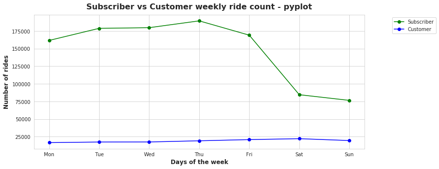

```python
# Customer Usage by Weekday vs. Subscriber Usage by Weekday
subscriber = df_cleaned_user_week.query("user_type == 'Subscriber'")
customer = df_cleaned_user_week.query("user_type == 'Customer'")

fig = plt.figure(figsize=(12, 5))
#create subplot for multiple point plots
ax1 = fig.add_subplot(111)

#plot of subscriber
ax1.plot(subscriber.start_time, subscriber.bike_id, label='Subscriber', color='green', marker='o')
#plot of customer
ax1.plot(customer.start_time, customer.bike_id, label='Customer', color='blue', marker='o')
plt.xticks([0,1,2,3,4,5,6],weekday)
plt.title("Subscriber vs Customer weekly ride count - pyplot", fontweight='bold', y =1.02, fontsize=16)
plt.xlabel('Days of the week',fontweight='bold', fontsize=12)
plt.ylabel('Number of rides',fontweight='bold', fontsize=12)

handles, labels = ax1.get_legend_handles_labels()
lgd = ax1.legend(handles, labels, loc='upper center', bbox_to_anchor=(1.15,1))

ax1.grid('on');
```

**We do notice that the company has a good amount of subscriber when compared to guest customers.** This could mean good news for the company since there will be users who will use the service regularly.

Now lets plot the same using Seaborn

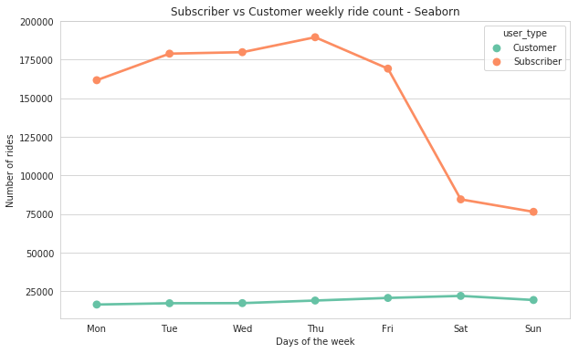

```python
#Number of rides per day using seaborn
plt.figure(figsize=(10,6))
ax = sb.pointplot(x='start_time', y='bike_id', palette='Set2', hue='user_type', data=df_cleaned_user_week);
ax.set_title('Subscriber vs Customer weekly ride count - Seaborn')
ax.set(xlabel='Days of the week', ylabel='Number of rides');
plt.xticks([0,1,2,3,4,5,6],weekday);
```

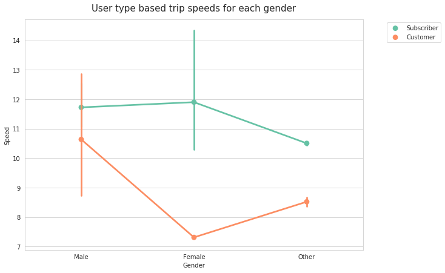

```python
plt.figure(figsize=(10,7))
ax = sb.pointplot(x='member_gender', y='speed', palette='Set2', hue='user_type', data=master_cleaned);
ax.set_title('User type based trip speeds for each gender',fontsize=15, y=1.02)
ax.set(xlabel='Gender', ylabel='Speed')

#plotting the legend outside the graph
handles, labels = ax.get_legend_handles_labels()
lgd = ax.legend(handles, labels, loc='upper center', bbox_to_anchor=(1.15,1))
```

The average male riding speeds among the subscribers seems to bit **slower** than the female users. This means females are faster in their rides than the males. The scenario changes when t comes to customers.

**Speed based on gender**

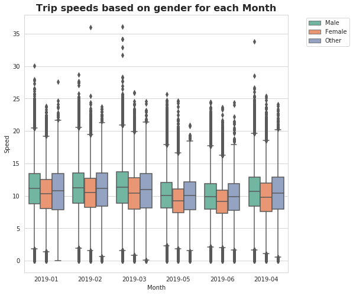

```python
plt.figure(figsize=(8,8))
# boxplot
ax = sb.boxplot(x='month', y='speed', palette='Set2', hue='member_gender', data=master_cleaned.query('speed < 100'))
ax.set_title('Trip speeds based on gender for each Month', fontweight='bold', fontsize=16)
ax.set(xlabel='Month', ylabel='Speed')

#legend outside the chart
handles, labels = ax.get_legend_handles_labels()
lgd = ax.legend(handles, labels, loc='upper center', bbox_to_anchor=(1.15,1))
```

1. The mean speed of Male users is bit highers than the other 2.
2. We can also see that the overall speed of all the 3 genders has come down for the month of May and June. This could be the **Summer effect** where people slow down due to **tiredness from heat**.

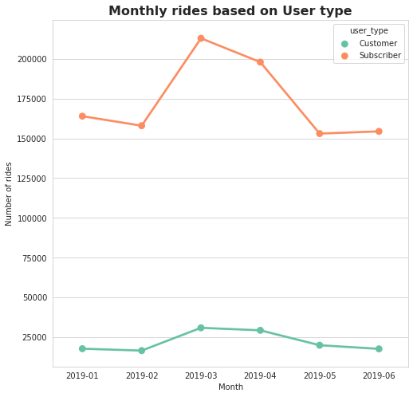

```python
plt.figure(figsize=(8,8))
ax = sb.pointplot(x='month', y='bike_id', palette='Set2', hue='user_type', data=monthly_user)
ax.set_title('Monthly rides based on User type',fontweight='bold', fontsize=16)
ax.set(xlabel='Month', ylabel='Number of rides');
```

### Talk about some of the relationships you observed in this part of the investigation. How did the feature(s) of interest vary with other features in the dataset?

1. The average speed is more for that of Males than the females and others.
2. When compared month on month, there is a steep increase in the riderships in the Month on March 2019 for both subscribers and the customers. the falls a bit in April and falls again in May.
3. The average male riding speeds among the subscribers seems to bit slower than the female users. This means females are faster in their rides than the males. The scenario changes when t comes to customers.

### Did you observe any interesting relationships between the other features (not the main feature(s) of interest)?

I noticed the interesting trends of decrease in speeds with different seasons. With Spring, The speeds are good and when there is Summer, the speeds come down. This could be with the tiredness coming in with the heat.

## Multivariate Exploration

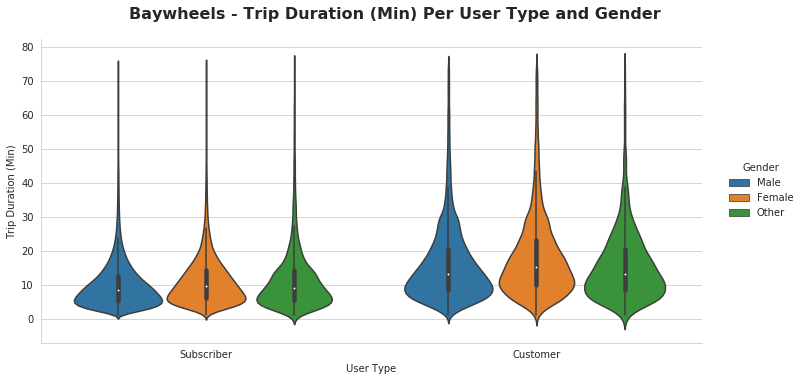

```python
graph = sb.catplot(data=master_cleaned.query('duration_min < 75'),
                   x='user_type', y='duration_min', hue="member_gender",
                   kind="violin", height=5, aspect=2);

graph.set_axis_labels("User Type", "Trip Duration (Min)")
graph._legend.set_title('Gender')
graph.fig.suptitle('Baywheels - Trip Duration (Min) Per User Type and Gender', y=1.05, fontsize=16, fontweight='bold');
```

The trip duration of customers looks to be greater than subscribers. This is mostly because guests customer use the service in the weekend for longer trips.

**Which are the busiest stations for Baywheels?**

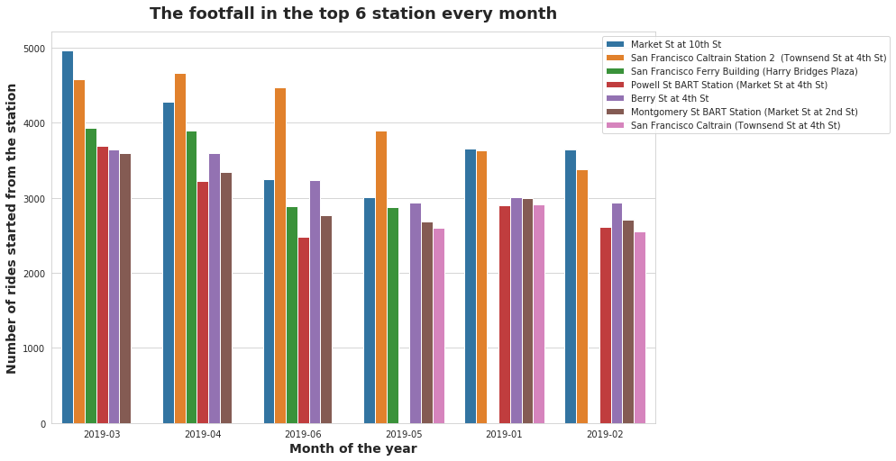

```python
plt.figure(figsize=(12,8))
ax = sb.barplot(x='month',y='bike_id',data=top_stations, hue='start_station_name')

plt.title("The footfall in the top 6 station every month", fontsize=18, fontweight='bold', y=1.02)
plt.xlabel('Month of the year', fontweight='bold', fontsize=14)
plt.ylabel('Number of rides started from the station', fontweight='bold', fontsize=14)

handles, labels = ax.get_legend_handles_labels()
lgd = ax.legend(handles, labels, loc='upper center', bbox_to_anchor=(1.15,1));
```

### Were there any interesting or surprising interactions between features?

```
                                                 Thank You!
                                                 Gautam Gadiyar
```